# Periodontology 2000 - Main Figures, Submitted

Diana Proctor

February 11, 2019

This script was used in conjunction with a script to generate figures for the paper “Title: Microbial biogeography and ecology of the mouth and implications for periodontal diseases” by

Diana M. Proctor1,2,10, Katie M. Shelef3,10, Antonio Gonzales4, Clara L. Davis Long5, Les Dethlefsen1, Adam Burns1, Peter M. Loomer6, Gary C. Armitage7, Mark I. Ryder7, Meredith E. Millman7, Rob Knight4, Susan P. Holmes8, David A. Relman1,5,9*

Originally published online at https://doi.org/10.1101/541052

We performed a case study to illustrate the application of some statistical and ecological models to the spatial analysis of oral microbial communities.

### Subjects

Specimens were collected from five individuals who had not taken antibiotics for at least three months and did not require antibiotics prior to dental visits. All subjects were non-smokers over the age of 21 and had at least 14 remaining teeth. Three subjects were female and two were male. Ages ranged from 25-39. One subject was African-American and four were Caucasian. Subjects were excluded if they had diabetes mellitus, HIV infection, blood dyscrasias, or were pregnant or lactating.

Complete periodontal examinations were conducted before sample collection. The periodontal status of subjects was determined by Dr. Peter Loomer at the UCSF School of Dentistry in 2012. The full-mouth periodontal assessments included probing depth (mm, PD), clinical attachment loss (mm, CAL), bleeding upon probing (yes/no, BOP), and the Plaque Index of Silnes and Loe (Silness and Loe 1964). All clinical measurements were recorded at 6 sites around each tooth (i.e. mesialbuccal, mesial, distobuccal, mesiolingual, and distolingual) with a North Carolina periodontal probe.

Subjects were considered periodontally healthy if on a full mouth basis they met the following criteria: 1) mean pre-treatment CAL of ≤ 0.5, 2) no interproximal sites with CAL ≥ 3, no PD > 4, 4) no more than 3% (5/168) sites with BOP, and 3) no more than 2 missing teeth with the exception of extracted third molars or teeth that are congenitally missing. One subject (male) was sampled at 34 subgingival sites, and one subject (female) was sampled at 32 subgingival sites (teeth 5 and 12 were excluded because they were missing)

### Sample collection

Whole saliva was collected by asking the patient to expectorate into a Nunc vial containing 200-μL of phosphate-buffered solution (PBS). All subjects were sampled at 5 soft tissue sites (dorsum of tongue, ventral tongue surface, hard palate, buccal mucosa, and keratinized buccal gingiva), and one saliva sample was collected from each individual.Soft tissue samples were collected with a sterile plastic spatula and subgingival samples were collected with a sterile curette.

Prior to sampling, subgingival sites were isolated with cotton rolls and gently dried with an air syringe. All samples were transferred to a Nunc collection vial containing 200-μL of PBS. Samples were then vortexed for 3 seconds and spun down briefly with a tabletop centrifuge. Vials were immediately frozen on dry ice and transported to the lab, where they were placed at -80 degrees Celsius for storage. In the image below, circles represent samples of subgingival sites that were sampled.

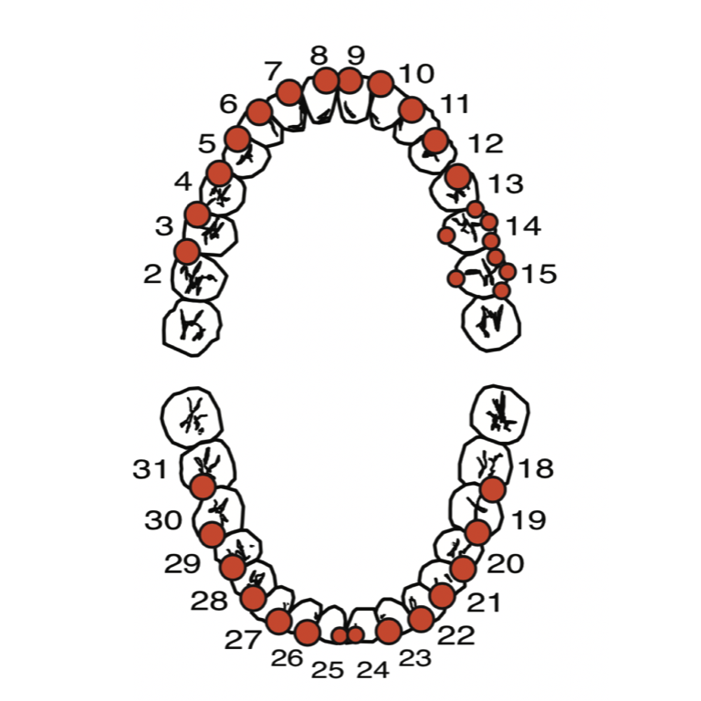

### DNA extraction

Collected samples were stored at -80°C for no more than 7 days before extraction. Sample DNA was extracted using the QIAamp DNA extraction mini kit (Qiagen) with an additional bead-beating step after the incubation at 94°C. To maximize diversity while minimizing loss during bead-beating, samples were split, half were bead-beat at 4.0 m/s for 30 seconds in a FastPrep machine, and the two halves were recombined. All downstream steps were performed on the combined sample.

### 16S gene amplification and sequencing

Over all subjects, a total of 135 subgingival samples were collected. Samples collected from seven subgingival sites (5.2%) were excluded from the analysis due to insufficient quantity of biomass for amplification. In addition, Illumina-generated sequences were discarded if the sequence contained one or more ambiguous bases, contained less than 75 bases in the high-quality region of the sequence, or the barcode was not an exact match to a barcode in the mapping file.

These procedures generated a dataset of 2,527,634 V4-specific 16S rRNA sequences.

### Sequence Data Analysis

Data were stored in Qiita and downloaded after demultiplexing sequences. The sequences were imported into R and were quality filtered with dada2 and subject to decontamination before analysis. For full details, refer to the Script “Periodontology 2000_Pre-Processing”.

### Import the data and load libraries

Note that the tooth labeled “tooth” is also labeled “Saliva” elsewhere in the mapping file, but the sampleID suggests that the data elsewhere in the mapping file is correct: 1032.72.2MB, i.e., it represents tooth 2mb. However, since it’s unclear whether this represents a subgingival or surpagingival sample it will be discarded.

How many samples are in the dataset?

```r
discovery = readRDS("~/Desktop/Personal/Perio2000_submitted/perio/katie_biogeo_tree.RDS")
discovery
```

```
## phyloseq-class experiment-level object
## otu_table()   OTU Table:         [ 1679 taxa and 84 samples ]
## sample_data() Sample Data:       [ 84 samples by 61 sample variables ]
## tax_table()   Taxonomy Table:    [ 1679 taxa by 6 taxonomic ranks ]
## phy_tree()    Phylogenetic Tree: [ 1679 tips and 1677 internal nodes ]
```

```r
#how many subjects
levels(sample_data(discovery)$Subject)
```

```
## [1] "72"  "73"  "XC3"
```

```r
#what's the median sequencing depth
summary(sample_sums(discovery))
```

```
##    Min. 1st Qu.  Median    Mean 3rd Qu.    Max.
##       2   22145   27413   28717   35102   75977
```

```r
#let's drop the sample whose site-origin is unknown
discovery = subset_samples(discovery, SampleID !="1032.72.2MB")
```

# Description of data: Phyla level composition of subgingival plaque

The top 5 phyla are proteobacteria, firmicutes, actinobacteria, bacteroidetes, and fusobacteria. These represent 98% of all reads.

```r
subgingival = subset_samples(discovery, SampleType=="subgingival tooth")
#how many unique phyla are found?
length(get_taxa_unique(subgingival, taxonomic.rank="Phylum"))
```

```
## [1] 26
```

```r
#What is the relative abundance of each Phylum?
phy <- tax_glom(subgingival, taxrank="Phylum")
      tax.count <- data.frame(taxa_sums(phy),tax_table(phy)[,2])
      rownames(tax.count)= NULL
      colnames(tax.count)[1] <- c("Abundance")
      tax.count$Percent <- round(tax.count$Abundance/sum(tax.count$Abundance)*100, 4)
      library(plyr)
      Phylum_df <- tax.count[with(tax.count, order(-Percent)), ]

      #how much do the top 5 phyla contribute to total abundance?
      top5 <- Phylum_df[1:5, ]
      round(sum(top5$Percent),2)
```

```
## [1] 97.84
```

```r
      #What are the top 5 Phyla?
      top5
```

```
##   Abundance         Phylum Percent
## 1    709113 Proteobacteria 38.0886
## 3    377074 Actinobacteria 20.2538
## 5    289845  Bacteroidetes 15.5685
## 2    283386     Firmicutes 15.2215
## 4    162078   Fusobacteria  8.7057
```

## Description of data: genus-level summary of subgingival plaque

Here, we look at the top 10 genera and the number of species of each.

```r
#What is the number of Genera found?
length(get_taxa_unique(subgingival, taxonomic.rank="Genus"))
```

```
## [1] 210
```

```r
#what are the abundance levels of each genus?
supra.genus <- tax_glom(subgingival, taxrank="Genus")
        tax.count <- data.frame(tax_table(supra.genus)[,2:6], taxa_sums(supra.genus))
        rownames(tax.count) = NULL
        colnames(tax.count) <- c("Phylum","Class","Order","Family","Genus",  "Abundance")
        tax.count$Percent <- round(tax.count$Abundance/sum(tax.count$Abundance)*100, 4)
        library(plyr)
        Genus_df <- tax.count[with(tax.count, order(-Percent)), ]

        #how much do the top 10 genera contribute to total abundance?
        top10 <- Genus_df[1:10, ]
        round(sum(top10$Percent),3)
```

```
## [1] 76.591
```

```r
###How diverse are the top 10 genera? i.e., how many species are there per genus?
top10 <- as.vector(Genus_df$Genus[1:10])
Diversity.list <- vector("list", 10)
names(Diversity.list) <- top10

for(i in 1:length(top10)){
       physub = subset_taxa(discovery, Genus==top10[i])
       physub = prune_taxa(taxa_sums(physub) > 0, physub)
       Diversity.list[[i]] <- physub
}

#compute the number of taxa in each element of the list
Ntaxa <- data.frame(unlist(lapply(Diversity.list, ntaxa)))

colnames(Ntaxa) <- "N.Species"
#Make a table with percent abundance and number of taxa
genus.tab <- data.frame(Genus_df[1:10,], Ntaxa)
library(knitr)
kable(genus.tab, format="markdown")
```

|  | Phylum | Class | Order | Family | Genus | Abundance | Percent | N.Species |
| --- | --- | --- | --- | --- | --- | --- | --- | --- |
| 2 | Actinobacteria | Actinobacteria | Actinomycetales | Micrococcaceae | Rothia | 188299 | 12.4120 | 7 |
| 6 | Proteobacteria | Betaproteobacteria | Neisseriales | Neisseriaceae | Neisseria | 158626 | 10.4561 | 9 |
| 13 | Bacteroidetes | Bacteroidia | Bacteroidales | Prevotellaceae | Prevotella | 146092 | 9.6299 | 41 |
| 7 | Fusobacteria | Fusobacteriia | Fusobacteriales | Fusobacteriaceae | Fusobacterium | 120932 | 7.9714 | 15 |
| 4 | Actinobacteria | Actinobacteria | Actinomycetales | Actinomycetaceae | Actinomyces | 120362 | 7.9339 | 15 |
| 1 | Firmicutes | Bacilli | Lactobacillales | Streptococcaceae | Streptococcus | 108958 | 7.1821 | 10 |
| 3 | Proteobacteria | Gammaproteobacteria | Pasteurellales | Pasteurellaceae | Haemophilus | 107212 | 7.0671 | 6 |
| 5 | Proteobacteria | Betaproteobacteria | Neisseriales | Neisseriaceae | Kingella | 93455 | 6.1602 | 3 |
| 11 | Bacteroidetes | Flavobacteriia | Flavobacteriales | Flavobacteriaceae | Capnocytophaga | 65410 | 4.3116 | 16 |
| 14 | Proteobacteria | Epsilonproteobacteria | Campylobacterales | Campylobacteraceae | Campylobacter | 52584 | 3.4662 | 9 |

# Figure 1: What taxa dominate the mouths of illumina sequenced subjects?

Code is shown for Panel A. Panel B of this figure was generated by SitePainter (http://biocore.github.io/SitePainter/), a utility developed by the Knight lab.

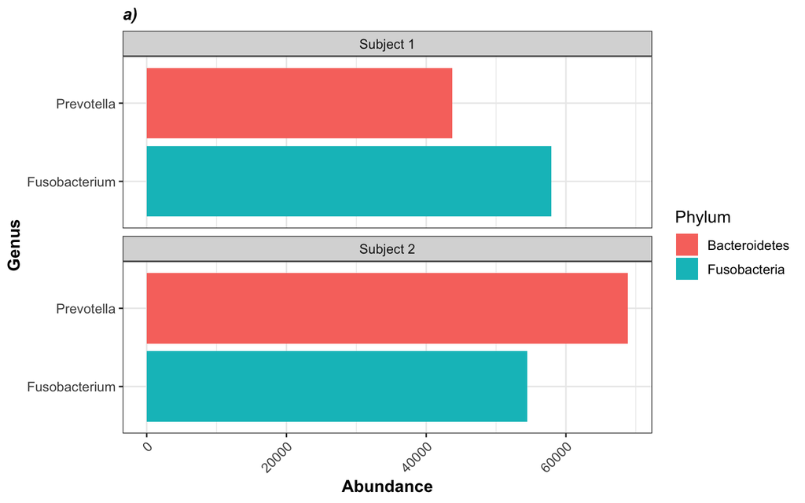

```r
#let's filter the taxa to retain only those that are present in 20 samples
filtergroup = filterfun(kOverA(k=20, A=1)) #k = number of samples; A = abundance
        filt_phy = filter_taxa(discovery, filtergroup, prune=TRUE)
        filt_phy = prune_samples(sample_sums(filt_phy) > 0, filt_phy)

#now let's look at the rank abundance curve for each subject independently
#further for each subject we're only going to look at the top 10 most abundant taxa
subjects = levels(as.factor(sample_data(filt_phy)$Subject))[1:2]

myTaxa = c("Prevotella",  "Fusobacterium")
mySubset = subset_taxa(filt_phy, Genus %in% myTaxa)
racurves <- vector('list', length(subjects))
names(racurves) = subjects
for(i in 1:length(subjects)){
          sub1 = subset_samples(mySubset, Subject==subjects[i])
          tax = data.frame(taxa_sums(sub1), tax_table(sub1))
          colnames(tax)[1] = "Abundance"
          tax <- tax[order(tax$Abundance, decreasing=TRUE),]
          tax$rank <- 1:ntaxa(sub1)
          tax$Subject = subjects[i]
          racurves[[i]] = tax
}

#now we can plot the rank abundance curves
df = do.call("rbind", racurves)
df$Subject = revalue(df$Subject, c("72"="Subject 1", "73"="Subject 2"))

p1 = ggplot(df, aes(Genus, Abundance, fill=Phylum)) + geom_bar(stat="identity")  +
      facet_wrap(~Subject, ncol=1) + coord_flip() +
      theme(plot.title = element_text(color="black", size=12, face="bold.italic"),
      axis.title.x = element_text(color="black", size=12, face="bold"),
      axis.title.y = element_text(color="black", size=12, face="bold"),
      text = element_text(size=12), axis.text.x = element_text(angle=45, hjust=1))  + ggtitle("a)")
p1
```

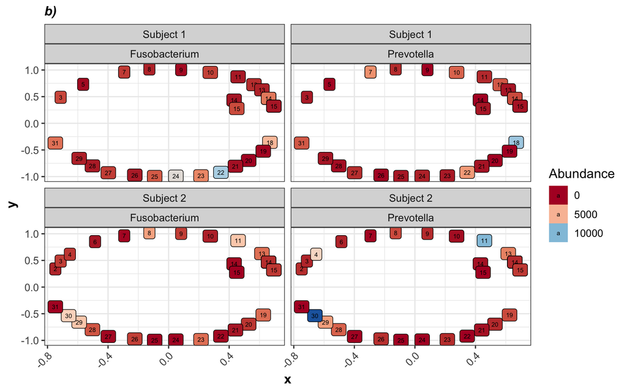

```r
#make a map of the distribution of these genera across sites
library(RColorBrewer)
myPalette = colorRampPalette(brewer.pal(8, "RdBu"), space="Lab")
myGlom = tax_glom(mySubset, "Genus")
myGlom = subset_samples(myGlom, Subject %in% c("72", 73))
tax = data.frame(tax_table(myGlom))
taxa_names(myGlom) = tax$Genus
df = data.frame(otu_table(myGlom), sample_data(myGlom))
df$Subject = revalue(df$Subject, c("72"="Subject 1", "73"="Subject 2"))

dfm = melt(df, id.vars = colnames(sample_data(myGlom)))
p2 = ggplot(dfm, aes(x, y, fill=value, label=Tooth_Number)) + facet_wrap(Subject~variable, ncol=2)+ geom_label(size=2)+
      scale_fill_gradientn(colours=myPalette(75))+
      theme(plot.title = element_text(color="black", size=12, face="bold.italic"),
      axis.title.x = element_text(color="black", size=12, face="bold"),
      axis.title.y = element_text(color="black", size=12, face="bold"),
      text = element_text(size=12), axis.text.x = element_text(angle=45, hjust=1))  + ggtitle("b)") +
      guides(fill=guide_legend(title="Abundance"))

p2
```

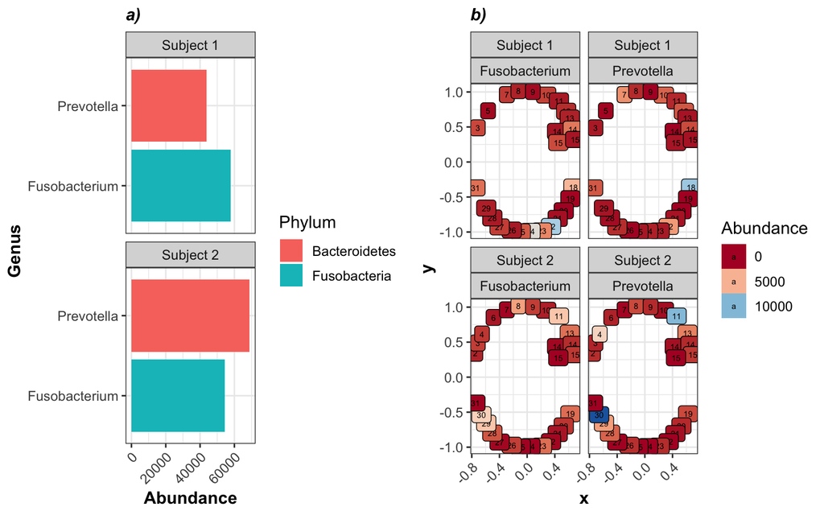

```r
#generate figure 1

grid.arrange(p1, p2, ncol=2)
```

```r
ggsave(grid.arrange(p1, p2, ncol=2), filename = "~/Desktop/Figure1.eps", device="eps", height =6, width = 11)
```

# Figure 2: What spatial pattern best describes subgingival communities?

Figure 2A: Use the trend surface analysis to look at broad scale spatial patterns

```r
subgingival = subset_samples(discovery, SampleType=="subgingival tooth")

#filter to retain taxa present in at least 2 samples
filtergroup = filterfun(kOverA(k=2, A=1)) #k = number of samples; A = abundance
        filt_phy = filter_taxa(subgingival, filtergroup, prune=TRUE)
        filt_phy = prune_taxa(taxa_sums(filt_phy) > 0, filt_phy)
        filt_phy = prune_samples(sample_sums(filt_phy) > 0, filt_phy)
        filt_phy
```

```
## phyloseq-class experiment-level object
## otu_table()   OTU Table:         [ 455 taxa and 61 samples ]
## sample_data() Sample Data:       [ 61 samples by 61 sample variables ]
## tax_table()   Taxonomy Table:    [ 455 taxa by 6 taxonomic ranks ]
## phy_tree()    Phylogenetic Tree: [ 455 tips and 453 internal nodes ]
```

```r
        library(vegan)
          #hellinger transform the data
          otus = data.frame(otu_table(filt_phy))
          otus.h = decostand(otus, "hellinger")
          map = sample_data(filt_phy)
          map$x = as.numeric(as.character(map$x))
          map$y = as.numeric(as.character(map$y))

          #center the coordinates
          xygrid = cbind(map$x, map$y)
          xygrid.c <- scale(xygrid, scale=FALSE)

          ### Compute the third-order orthogonal polynomial function using centered geographic coordinates
          poly.xy3 <- poly(xygrid.c, degree = 3, raw=FALSE) #, coefs=TRUE)
          colnames(poly.xy3) <- c("X", "X^2", "X^3", "Y", "XY", "X^2Y", "Y^2", "XY^2", "Y^3")
          poly.xy3.df <- data.frame(poly.xy3, map$x, map$y)

          library(ade4)
          #perform the RDA on the hellinger transformed data; extract the coordinates
          rld.pca <- dudi.pca(otus.h , center=TRUE, scale=TRUE, scannf=FALSE, nf=10)
          rld.xy3 <- pcaiv(rld.pca, poly.xy3, scannf = FALSE, nf = 6)
          rld.xy3.df <- data.frame(rld.xy3$ls, map)
          xy3.df <- data.frame(rld.xy3.df, poly.xy3)

          # how much of the variance does the trend surface model explain?
          rld.xy3.var <- sum(rld.xy3$eig)/sum(rld.pca$eig)*100
          rld.xy3.var
```

```
## [1] 17.84867
```

```r
          #look at the eigenvalues
          rld.xy3$eig
```

```
## [1] 23.748742 12.779811 11.712689  7.326080  6.688006  6.305238  4.674763
## [8]  4.129418  3.846705
```

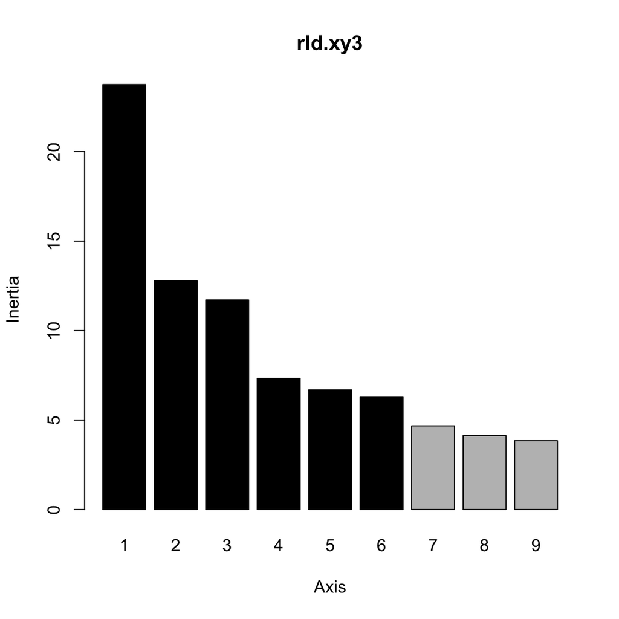

```r
          #look at the screeplot
          screeplot(rld.xy3) #we should look at the first 3 axes
```

```r
          #what is the percent of ewxplained variance
          Explainedvariance = rld.xy3$eig/sum(rld.xy3$eig)*100
          Explainedvariance
```

```
## [1] 29.243094 15.736464 14.422460  9.020994  8.235299  7.763977  5.756286
## [8]  5.084774  4.736653
```

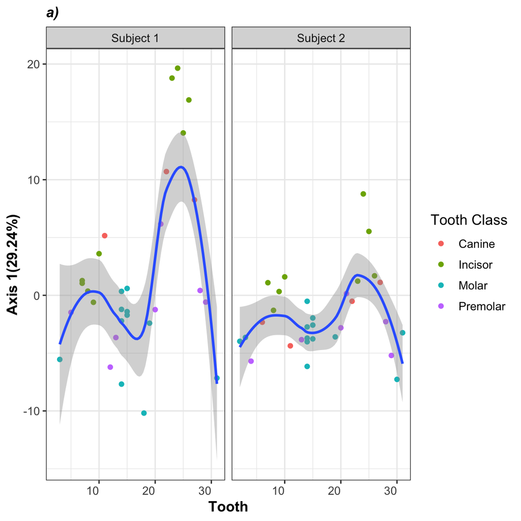

```r
          #force x, y to numeric
          xy3.df$x <- as.numeric(as.character(xy3.df$x))
          xy3.df$y <- as.numeric(as.character(xy3.df$y))


### Force variables to order in ggplot
order=1:32
xy3.df$Tooth_Number <- factor(xy3.df$Tooth_Number, as.character(order))
xy3.df$Tooth_Number <- as.numeric(xy3.df$Tooth_Number)

#plot axis 1
xy3.df$MyToothClass = xy3.df$Tooth_Class
xy3.df$MyToothClass = revalue(xy3.df$MyToothClass, c("Incisor_Central"="Incisor", "Incisor_Lateral"="Incisor"))

xy3.df$Subject = revalue(xy3.df$Subject, c("72"="Subject 1", "73"="Subject 2"))


fig2a = ggplot(xy3.df, aes(Tooth_Number, Axis1))  + theme_bw() + ylab("Axis 1") +
      xlab("Tooth")  + geom_point(aes(color=MyToothClass))+ geom_smooth() + ylab("Axis 1(29.24%)") +
      guides(color=guide_legend(title="Tooth Class"))+
      theme(plot.title = element_text(color="black", size=12, face="bold.italic"),
      axis.title.x = element_text(color="black", size=12, face="bold"),
      axis.title.y = element_text(color="black", size=12, face="bold"),
      text = element_text(size=12), axis.text.x = element_text(angle=0, hjust=1))  + facet_wrap(~Subject) +
      ggtitle("a)")

fig2a
```

## Figure 2B, Moran’s Eigenvector Maps (MEM) to identify broad and fine scale spatial patterns

MEM

- Note: the code here is from the Vignette: Stephane Dray, 2008. Moran’s eigenvectors of spatial weighting of matrices in R.
- The analysis above raises two questions related to the question or how a neighborhood should be defined since an arbitrary cutoff is used to define what is near and what is not. MEM offers a flexible way of solving this problem by allowing for construction of multiple models each differing in their definition of neighbor. Different model selection parameters can then be used to choose the model that explains the most variance

##### Generate the neighbor graph

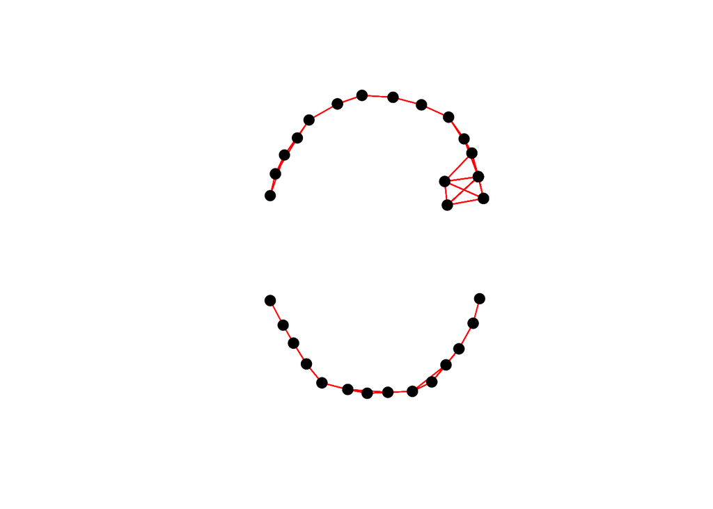

```r
path="~/Desktop/Personal/Perio2000_submitted/PCNM/sedar-master/pkg/PCNM/R"
myPCNM_in <- sort(list.files(path, pattern="*R", full.names = TRUE))

for(i in 1:length(myPCNM_in)) {
    source(myPCNM_in[[i]])
}


#subset on the buccal aspect
map = data.frame(sample_data(filt_phy))
map <- map[order(map$Tooth_Number),]

nbear1 <- dnearneigh(xygrid, 0, 0.3)
plot(nbear1, xygrid, col="red", pch=20, cex=2)
```

```r
#compute the euclidean distances between sites and select for neighbors
dist_nbear1 <- nbdists(nbear1, xygrid)
str(dist_nbear1)
```

```
## List of 61
##  $ : num [1:4] 0.202 0.199 0.202 0.199
##  $ : num [1:5] 0.202 0.181 0.29 0.202 0.29
##  $ : num [1:11] 0.181 0.109 0.274 0.274 0.274 ...
##  $ : num [1:12] 0.29 0.109 0.166 0.166 0.266 ...
##  $ : num [1:11] 0.274 0.166 0.23 0.151 0.285 ...
##  $ : num [1:11] 0.274 0.166 0.23 0.151 0.285 ...
##  $ : num [1:15] 0.266 0.23 0.23 0.23 0.287 ...
##  $ : num [1:11] 0.274 0.166 0.23 0.151 0.285 ...
##  $ : num [1:11] 0.151 0.151 0.287 0.151 0.249 ...
##  $ : num [1:13] 0.285 0.285 0.161 0.285 0.249 ...
##  $ : num [1:11] 0.151 0.151 0.287 0.151 0.249 ...
##  $ : num [1:2] 0.172 0.172
##  $ : num [1:3] 0.172 0.198 0.198
##  $ : num [1:6] 0.198 0.14 0.29 0.198 0.14 ...
```

[output cut: 49 more lines]

```r
#define weights as a function of distance
fdist <- lapply(dist_nbear1, function(x) 1-x/max(dist(xygrid)))

#create the spatial weights
listw_nbear1 = nb2listw(nbear1, glist=fdist, style="B")
listw_nbear1
```

```
## Characteristics of weights list object:
## Neighbour list object:
## Number of regions: 61
## Number of nonzero links: 396
## Percentage nonzero weights: 10.6423
## Average number of links: 6.491803
##
## Weights style: B
## Weights constants summary:
##    n   nn       S0       S1       S2
## B 61 3721 356.3078 641.7815 10928.86
```

#### Select the spatial weighting matrix

```r
 #fau <- sqrt(otus/outer(apply(otus, 1, sum), rep(1, ncol(otus)), "*"))
 #detrend
 faudt <- resid(lm(as.matrix(otus.h) ~ as.matrix(xygrid)))
library(spacemakeR)
 sc.nbear1 = scores.listw(listw_nbear1)
 AIC.nbear1 = ortho.AIC(faudt, sc.nbear1$vectors)
 AIC.nbear1
```

```
##  [1] -42.4484779 -41.7953199 -40.9688828 -39.9974661 -38.7297877
##  [6] -37.3837689 -35.8440650 -34.2208500 -32.5082700 -30.6753310
## [11] -28.7175007 -26.6190082 -24.3776905 -21.9896680 -19.4581112
## [16] -16.7055663 -13.7894481 -10.5202915  -7.0432563  -3.2700216
## [21]   0.7450946   5.0163301   9.5797872  14.4658341  19.7536724
## [26]  25.4045043  31.5638541  38.4448318  45.9727105
```

```r
 #get the min AIC
 min(AIC.nbear1, na.rm=TRUE)
```

```
## [1] -42.44848
```

```r
 which.min(AIC.nbear1)
```

```
## [1] 1
```

```r
 #test.W takes 2 arguments (response matrix, object of class nb); it returns the best model
 nbear1.res = test.W(faudt, nbear1)
```

```
##
##
## AICc for the null model: -42.8743133898038
##
## Best spatial model:
##        AICc NbVar
## 1 -42.41396     1
```

```r
 names(nbear1.res)
```

```
## [1] "all"  "best"
```

```r
 names(nbear1.res$best)
```

```
## [1] "values"  "vectors" "call"    "AICc"    "AICc0"   "ord"     "R2"
```

```r
 #estimate the best values of the parameters
  f2 <- function(x, dmax, y) {
     1 - (x^y)/(dmax)^y
 }
 maxi <- max(unlist(nbdists(nbear1, as.matrix(xygrid))))

 tri.f2 <- test.W(faudt, nbear1, f = f2, y = 2:10, dmax = maxi,
xy = xygrid)
```

```
##
##
## AICc for the null model: -42.8743133898038
##
## Best spatial model:
##   y      dmax      AICc NbVar
## 1 2 0.2916406 -42.79266     1
```

```r
 names(tri.f2$best)
```

```
## [1] "values"  "vectors" "call"    "AICc"    "AICc0"   "ord"     "R2"
```

```r
 myspec = variogmultiv(faudt, xygrid, nclass=20)
 myspec
```

```
## $d
##  [1] 0.05082135 0.15246406 0.25410677 0.35574948 0.45739219 0.55903489
##  [7] 0.66067760 0.76232031 0.86396302 0.96560573 1.06724843 1.16889114
## [13] 1.27053385 1.37217656 1.47381927 1.57546197 1.67710468 1.77874739
## [19] 1.88039010 1.98203281
##
## $var
##  [1]       NaN 0.4584487 0.5210720 0.4880341 0.5088920 0.4886696 0.5193172
##  [8] 0.4991221 0.5277461 0.5171191 0.5255143 0.4767192 0.4604853 0.4986048
## [15] 0.5117329 0.4619231 0.4707972 0.4584701 0.4430806 0.4502378
##
## $n.c
##  [1]  0 61 45 50 59 39 51 53 54 59 53 51 46 53 49 54 57 51 37 24
##
## $n.w
##  [1]   0 116  82  63  78  53  68  71  71 102  79 101  96 110  88 108 171
## [18] 113  96 114
##
## $dclass
##  [1] "(0,0.102]"     "(0.102,0.203]" "(0.203,0.305]" "(0.305,0.407]"
##  [5] "(0.407,0.508]" "(0.508,0.61]"  "(0.61,0.711]"  "(0.711,0.813]"
##  [9] "(0.813,0.915]" "(0.915,1.02]"  "(1.02,1.12]"   "(1.12,1.22]"
## [13] "(1.22,1.32]"   "(1.32,1.42]"   "(1.42,1.52]"   "(1.52,1.63]"
## [17] "(1.63,1.73]"   "(1.73,1.83]"   "(1.83,1.93]"   "(1.93,2.03]"
```

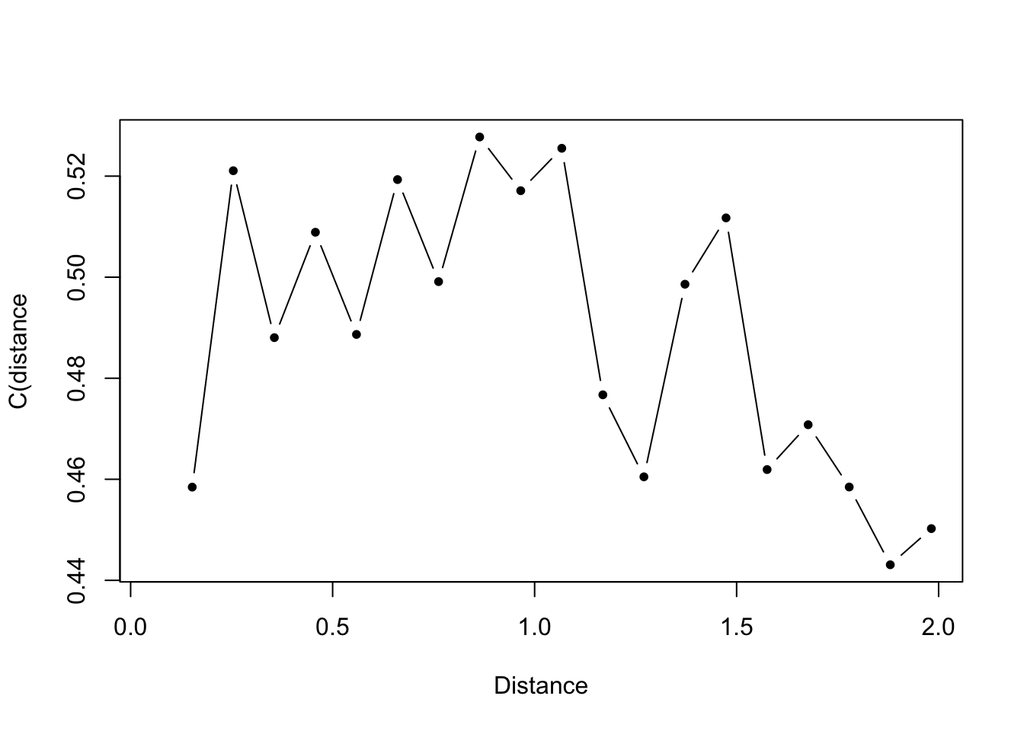

```r
 plot(myspec$d, myspec$var, ty="b", pch=20, xlab="Distance", ylab=("C(distance"))
```

#### construct 20 neighborhood matrices

```r
#create 20 different models at differing thresholds
dxy = seq(give.thresh(dist(xygrid)), 5, le=20)
nbdnnlist <- lapply(dxy, dnearneigh, x = xygrid, d1 = 0)

#test the best model across this list of 20 different models
dmn.bin = lapply(nbdnnlist, test.W, Y=faudt)
```

```
##
##
## AICc for the null model: -42.8743133898038
##
## Best spatial model:
##        AICc NbVar
## 1 -43.08087     1
##
##
## AICc for the null model: -42.8743133898038
##
## Best spatial model:
##        AICc NbVar
## 1 -43.36487     1
##
##
## AICc for the null model: -42.8743133898038
##
## Best spatial model:
##        AICc NbVar
## 1 -42.15569     1
##
##
## AICc for the null model: -42.8743133898038
##
## Best spatial model:
##        AICc NbVar
## 1 -42.84455     1
##
##
## AICc for the null model: -42.8743133898038
##
## Best spatial model:
##        AICc NbVar
## 1 -42.78331     1
##
##
## AICc for the null model: -42.8743133898038
##
## Best spatial model:
```

[output cut: 85 more lines]

```
## 1 -42.4739     1
##
##
## AICc for the null model: -42.8743133898038
##
## Best spatial model:
##       AICc NbVar
## 1 -42.4739     1
##
##
## AICc for the null model: -42.8743133898038
##
## Best spatial model:
##       AICc NbVar
## 1 -42.4739     1
```

```r
length(dmn.bin)
```

```
## [1] 20
```

```r
#for each nb we can find the lowest AIC
minAIC = sapply(dmn.bin, function(x) min(x$best$AICc, na.rm = T))
which.min(minAIC)
```

```
## [1] 2
```

```r
dxy[which.min(minAIC)]
```

```
## [1] 0.8983852
```

#### Extract the best model

```r
MEM.champ = unlist(dmn.bin[which.min(minAIC)], recursive = FALSE)
summary(MEM.champ)
```

```
##      Length Class      Mode
## all  2      data.frame list
## best 7      -none-     list
```

```r
MEM.champ$best$values #eigenvalues
```

```
##  [1] 19.01932895 10.51212002  6.12137502  3.12575145  0.55116602
##  [6]  0.23010552 -0.04884682 -0.29959435 -0.54567217 -0.81217988
## [11] -0.91739246 -1.00000000 -1.28849676 -1.35561347 -1.66399704
## [16] -2.00000000 -2.36400311 -2.59367168 -2.88965382 -3.02136664
## [21] -3.11957450 -3.35456176 -3.55984467 -4.26923459 -4.48978851
## [26] -5.08411269 -6.91515865 -7.57364077
```

```r
MEM.champ$best$ord #MEM variables by order of R2
```

```
##  [1]  4  7 18  8 16  9 14 24 27 25 19 22 12 21 13 28  3 10  5 20 26  6 23
## [24] 17 15 11  2  1
```

```r
#MEM variables selected in the best model
mem_ID = MEM.champ$best$ord[1:which.min(MEM.champ$best$AICc)]
length(mem_ID)
```

```
## [1] 1
```

```r
sort(mem_ID)
```

```
## [1] 4
```

```r
MEM.all <- MEM.champ$best$vectors
MEM.select <- MEM.champ$best$vectors[,sort(c(mem_ID))]


#unadjusted of the best model
R2.membest = MEM.champ$best$R2[which.min(MEM.champ$best$AICc)]

#adjusted of the best model
RsquareAdj(R2.membest, nrow(otus.h), length(mem_ID))
```

```
## [1] 0.02595916
```

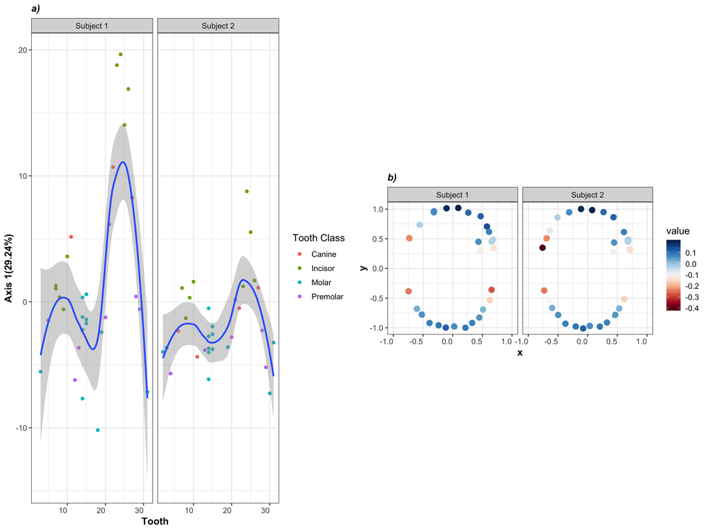

```r
df = data.frame(MEM.select, sample_data(filt_phy))
df$x = as.numeric(as.character(df$x))
df$y = as.numeric(as.character(df$y))
dfm = melt(df, id.vars = colnames(sample_data(filt_phy)))

#plot the fitted model
myPalette = colorRampPalette(brewer.pal(11, "RdBu"), space="Lab")
dfm$variable = revalue(dfm$variable, c("MEM.select"="Best MEM Model"))
dfm$Subject = revalue(dfm$Subject, c("72"="Subject 1", "73"="Subject 2"))

fig2b = ggplot(dfm, aes(x, y, color=value)) + geom_point(aes(x=x, y=y)) + coord_fixed() +
        scale_x_continuous(limits=c(-1,1)) + geom_jitter(position=position_jitter(width=0.025, height = 0.025), size=3) +
        scale_color_gradientn(colours=myPalette(100)) + theme_bw()  +
        theme(plot.title = element_text(color="black", size=12, face="bold.italic"),
         axis.title.x = element_text(color="black", size=12, face="bold"),
         axis.title.y = element_text(color="black", size=12, face="bold"),
         text = element_text(size=12), axis.text.x = element_text(angle=0, hjust=1))  + facet_wrap(~Subject) +
          ggtitle("b)")


grid.arrange(fig2a, fig2b, ncol=2)
```

```r
ggsave(grid.arrange(fig2a, fig2b, ncol=2), filename = "~/Desktop/Figure2.eps", device="eps", height =5, width = 11)
```

```r
library(vegan)
fm.mem.rda = rda(otus.h~., as.data.frame(MEM.select))
fm.MEM.r2a = RsquareAdj(fm.mem.rda)$adj.r.squared
fm.MEM.r2a
```

```
## [1] 0.02385587
```

```r
anova.cca(fm.mem.rda)
```

```
## Permutation test for rda under reduced model
## Permutation: free
## Number of permutations: 999
##
## Model: rda(formula = otus.h ~ MEM.select, data = as.data.frame(MEM.select))
##          Df Variance      F Pr(>F)
## Model     1  0.02058 2.4663  0.005 **
## Residual 59  0.49233
## ---
## Signif. codes:  0 '***' 0.001 '**' 0.01 '*' 0.05 '.' 0.1 ' ' 1
```

```r
#how many axes are significant
axes.mem.test = anova.cca(fm.mem.rda, by="axis")
axes.mem.test
```

```
## Permutation test for rda under reduced model
## Forward tests for axes
## Permutation: free
## Number of permutations: 999
##
## Model: rda(formula = otus.h ~ MEM.select, data = as.data.frame(MEM.select))
##          Df Variance      F Pr(>F)
## RDA1      1  0.02058 2.4663  0.006 **
## Residual 59  0.49233
## ---
## Signif. codes:  0 '***' 0.001 '**' 0.01 '*' 0.05 '.' 0.1 ' ' 1
```

```r
#how many terms are significant
terms.mem.test = anova.cca(fm.mem.rda, by="terms")
terms.mem.test
```

```
## Permutation test for rda under reduced model
## Terms added sequentially (first to last)
## Permutation: free
## Number of permutations: 999
##
## Model: rda(formula = otus.h ~ MEM.select, data = as.data.frame(MEM.select))
##            Df Variance      F Pr(>F)
## MEM.select  1  0.02058 2.4663  0.006 **
## Residual   59  0.49233
## ---
## Signif. codes:  0 '***' 0.001 '**' 0.01 '*' 0.05 '.' 0.1 ' ' 1
```

# Figure 3: Ecological model - application of metacommunity theory to subgingival communities

### Look at Coherence

```r
library(metacom)
subjects = levels(sample_data(filt_phy)$Subject)
sub_Cohere <- vector('list', length(subjects))
names(sub_Cohere) = subjects
for(i in 1:length(subjects)){
            s1 = subset_samples(filt_phy, Subject==subjects[[i]])
            s1 = prune_taxa(taxa_sums(s1) > 0, s1)
            s1 = prune_samples(sample_sums(s1) > 0, s1)
            hab = merge_samples(s1, "Habitat.Specific")
            otus = data.frame(otu_table(hab))
            otus.pa = decostand(otus, "pa")
            cohere.out = Coherence(otus.pa, method = "r1", sims = 999, scores = 1, order = TRUE,
                                   allowEmpty = TRUE, binary = TRUE, verbose = TRUE, seed = 1)
            sub_Cohere[[i]] = cohere.out
}

fm = do.call("rbind", sub_Cohere)
foo= colsplit(rownames(fm), "([.])", c("Subject", "junk"))
fm$Subject = foo$Subject

#subset on features for plotting
Cohere = subset(fm, name %in% c("embAbs", "simMean"))
Cohere$Subject = revalue(as.factor(Cohere$Subject), c("72"="Subject 1", "73"="Subject 2"))

p1 = ggplot(Cohere, aes(name, stat)) + geom_boxplot() + ylab("Number of embedded absences") + xlab("")+
        geom_point(size=4, aes(color=as.factor(Subject))) + guides(color = guide_legend(title = "Subject")) +
      theme(plot.title = element_text(color="black", size=12, face="bold.italic"),
      axis.title.x = element_text(color="black", size=12, face="bold"),
      axis.title.y = element_text(color="black", size=12, face="bold"),
      text = element_text(size=12), axis.text.x = element_text(angle=45, hjust=1))  + ggtitle("a)")
```

### Look at Turnover

```r
subjects = levels(sample_data(filt_phy)$Subject)
sub_Turnover <- vector('list', length(subjects))
names(sub_Turnover) = subjects
for(i in 1:length(subjects)){
          s1 = subset_samples(filt_phy, Subject==subjects[[i]])
          s1 = prune_taxa(taxa_sums(s1) > 0, s1)
          s1 = prune_samples(sample_sums(s1) > 0, s1)
          hab = merge_samples(s1, "Habitat.Specific")
          otus = data.frame(otu_table(hab))
          otus.pa = decostand(otus, "pa")
          turn.out = Turnover(otus.pa, method = "r1", sims = 999, scores = 1, order = TRUE,
                              allowEmpty = TRUE, binary = TRUE, verbose = TRUE)
          sub_Turnover[[i]] = turn.out
}

fm = do.call("rbind", sub_Turnover)
foo= colsplit(rownames(fm), "([.])", c("Subject", "junk"))
fm$Subject = foo$Subject

#subset on features for plotting
turn = subset(fm, name %in% c("turnover", "simMean"))
turn$Subject = revalue(as.factor(turn$Subject), c("72"="Subject 1", "73"="Subject 2"))

p2 = ggplot(turn, aes(name, stat)) + geom_boxplot() + geom_point(size=3, aes(color=as.factor(Subject))) +
      ylab("Species turnover across sites") + xlab("")+
      theme(plot.title = element_text(color="black", size=12, face="bold.italic"),
      axis.title.x = element_text(color="black", size=12, face="bold"),
      axis.title.y = element_text(color="black", size=12, face="bold"),
      text = element_text(size=12), axis.text.x = element_text(angle=45, hjust=1))  +
      guides(color = guide_legend(title = "Subject")) + ggtitle("b)")
```

### Look at boundary clumping

```r
subjects = levels(sample_data(filt_phy)$Subject)
sub_clump <- vector('list', length(subjects))
names(sub_clump) = subjects
for(i in 1:length(subjects)){
          s1 = subset_samples(filt_phy, Subject==subjects[[i]])
          s1 = prune_taxa(taxa_sums(s1) > 0, s1)
          s1 = prune_samples(sample_sums(s1) > 0, s1)
          hab = merge_samples(s1, "Habitat.Specific")
          otus = data.frame(otu_table(hab))
          otus.pa = decostand(otus, "pa")
          boucl.pa = BoundaryClump(otus.pa, order = TRUE, scores = 1, binary = TRUE, fill = TRUE)
          sub_clump[[i]] = boucl.pa
}


fm = do.call("rbind", sub_clump)
foo= colsplit(rownames(fm), "([.])", c("Subject", "junk"))
fm$Subject = foo$Subject

#subset on features for plotting
bound = subset(fm, name %in% c("index"))
bound$Subject = revalue(as.factor(bound$Subject), c("72"="Subject 1", "73"="Subject 2"))

p3 = ggplot(bound, aes(name, stat)) +
      geom_point(size=3, aes(color=as.factor(Subject))) + xlab("")+
      theme(plot.title = element_text(color="black", size=12, face="bold.italic"),
      axis.title.x = element_text(color="black", size=12, face="bold"),
      axis.title.y = element_text(color="black", size=12, face="bold"),
      text = element_text(size=12), axis.text.x = element_text(angle=45, hjust=1))  +
      ylab("Morisita Index (Boundary Clumping)")+ guides(color = guide_legend(title = "Subject")) + ggtitle("c)")
```

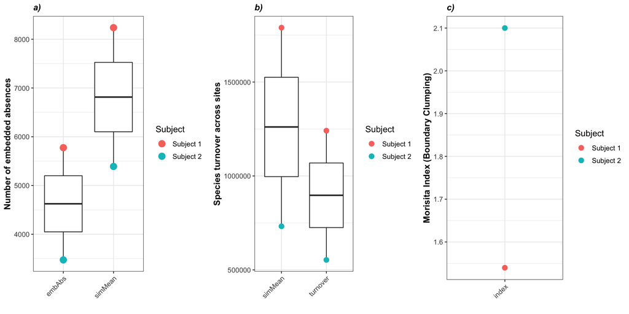

```r
grid.arrange(p1, p2, p3, ncol=3)
```

```r
ggsave(grid.arrange(p1, p2, p3, ncol=3), filename = "~/Desktop/Figure3.eps", device="eps", height =5, width = 11)
```

# Figure 4: Looking at the Neutral Model

This model was generated by Katie Shelef as described in her thesis: http://purl.stanford.edu/wp568qs4457

# Table 1: Looking at dispersal using two distance models

## Model 1: The straight line distance, Euclidean distance

```r
#########################Typodant
# test Mantel on the typodant model - Subject 1
M1 = data.table::fread("Distance_matrix_Illumina_DirectMeasurement_Sub72AllAspects.txt")
M1 = M1[,-1]
  my72 = subset_samples(subgingival, Subject==72)
  my72 = prune_taxa(taxa_sums(my72) > 0, my72)
  my72 = as.matrix(otu_table(my72))
  brayM = vegdist(my72, "bray")
  mantel.bray = mantel(brayM, M1, permutations=9999)
  mantel.bray
```

```
##
## Mantel statistic based on Pearson's product-moment correlation
##
## Call:
## mantel(xdis = brayM, ydis = M1, permutations = 9999)
##
## Mantel statistic r: 0.2571
##       Significance: 4e-04
##
## Upper quantiles of permutations (null model):
##    90%    95%  97.5%    99%
## 0.0851 0.1131 0.1367 0.1665
## Permutation: free
## Number of permutations: 9999
```

```r
# test Mantel on the typodant model- Subject 2
M2 = data.table::fread("Distance_matrix_Illumina_DirectMeasurement_Sub73AllAspects.txt")
names = M2[,1]
M2 = M2[,-1]

  my73 = subset_samples(subgingival, Subject=="73")
  my73 = subset_samples(my73, !(Specifier.Specific %in% c("Sub_15L"))) #not in distance matrix, drop it
  my73 = merge_samples(my73, "Specifier.Specific")
  my73 = as.matrix(otu_table(my73))
  brayM = vegdist(my73, "bray")
  mantel1.bray = mantel(brayM, M2, permutations=9999)
  mantel1.bray
```

```
##
## Mantel statistic based on Pearson's product-moment correlation
##
## Call:
## mantel(xdis = brayM, ydis = M2, permutations = 9999)
##
## Mantel statistic r: 0.05997
##       Significance: 0.1806
##
## Upper quantiles of permutations (null model):
##    90%    95%  97.5%    99%
## 0.0864 0.1141 0.1386 0.1672
## Permutation: free
## Number of permutations: 9999
```

## Model 2: distances measured as # of Teeth apart

```r
  # test Mantel on the typodant model - Subject 1
M1 = data.table::fread("~/Desktop/Personal/Perio2000_submitted/perio/Distance_matrix_illumina_NumberTeethApart_Sub72AllAspects.txt")
M1 = M1[,-1]
  my72 = subset_samples(subgingival, Subject=="72")
  my72 = prune_taxa(taxa_sums(my72) > 0, my72)
  my72 = as.matrix(otu_table(my72))
  brayM = vegdist(my72, "bray")
  mantel.bray = mantel(brayM, M1, permutations=9999)
  mantel.bray
```

```
##
## Mantel statistic based on Pearson's product-moment correlation
##
## Call:
## mantel(xdis = brayM, ydis = M1, permutations = 9999)
##
## Mantel statistic r: 0.145
##       Significance: 0.027
##
## Upper quantiles of permutations (null model):
##    90%    95%  97.5%    99%
## 0.0906 0.1184 0.1478 0.1898
## Permutation: free
## Number of permutations: 9999
```

```r
# test Mantel on the typodant model- Subject 2
M2 = data.table::fread("~/Desktop/Personal/Perio2000_submitted/perio/Distance_matrix_illumina_NumberTeethApart_Sub73AllAspects.txt")
names = M2[,1]
M2 = M2[,-1]

  my73 = subset_samples(subgingival, Subject=="73")
  my73 = subset_samples(my73, !(Specifier.Specific %in% c("Sub_15L")))
  my73 = merge_samples(my73, "Specifier.Specific")
  my73 = as.matrix(otu_table(my73))
  brayM = vegdist(my73, "bray")
  mantel1.bray = mantel(brayM, M2, permutations=9999)
  mantel1.bray
```

```
##
## Mantel statistic based on Pearson's product-moment correlation
##
## Call:
## mantel(xdis = brayM, ydis = M2, permutations = 9999)
##
## Mantel statistic r: 0.07299
##       Significance: 0.1194
##
## Upper quantiles of permutations (null model):
##    90%    95%  97.5%    99%
## 0.0805 0.1078 0.1343 0.1640
## Permutation: free
## Number of permutations: 9999
```